# Reproducible Research: Peer Assessment 1

This assigned written by Vladimir Pavlovic for the sole purpose of the coursera course on Reproducable Research. Note that it is assumed that the activity data is already uncompressed, and that it is at the same folder as the running program.

## Loading and preprocessing the data

```r
actData <- read.csv("activity.csv")
```

## What is mean total number of steps taken per day?

Process the input activity data to generate a histogram of the total number of steps taken each day.

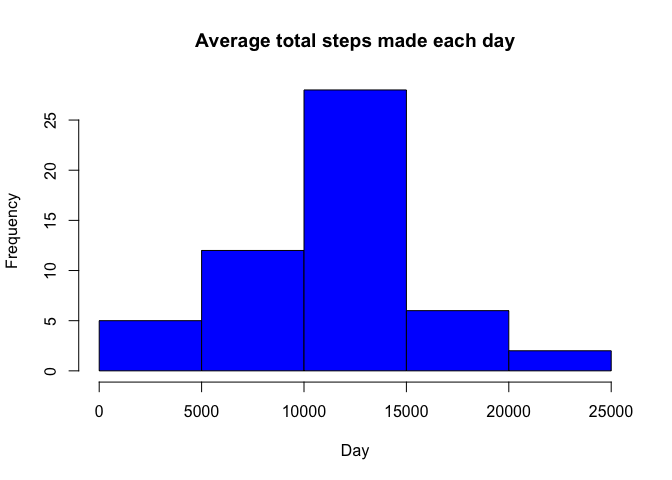

```r
totalSteps <- aggregate(steps ~ date, data = actData, FUN=sum, na.rm = TRUE)
hist(totalSteps$steps, main = "Average total steps made each day", xlab = "Day",
     col = "blue")
```

Mean value is:

```r
mean(totalSteps$steps)
```

```
## [1] 10766.19
```

Median values is:

```r
median(totalSteps$steps)
```

```
## [1] 10765
```

## What is the average daily activity pattern?

Calculate the time series of the daily activity pattern, and later plot it.

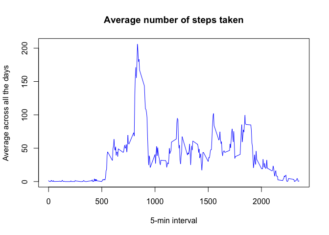

```r
dact <- tapply(actData$steps, actData$interval, FUN=mean, na.rm = TRUE)
plot(row.names(dact), dact, type = "l", xlab = "5-min interval",
    ylab = "Average across all the days",
    main = "Average number of steps taken",
    col = "blue")
```

## Imputing missing values

Extract the number of missing values:

```r
missingValuesBool <- is.na(actData)
missingValues <- sum(missingValuesBool)
missingValues
```

```
## [1] 2304
```

Creating a new dataset with the NA value replaced by the median values.

```r
actDataReplaced <-actData
medianData <-tapply(actData$steps, actData$interval, FUN=median,
                    na.rm=TRUE)
for (i in which(is.na(actDataReplaced)))
    {
    actDataReplaced[i,1] <- medianData[((i-1)%%288)+1]
    }
```

Histogram of the total number of steps taken each day.

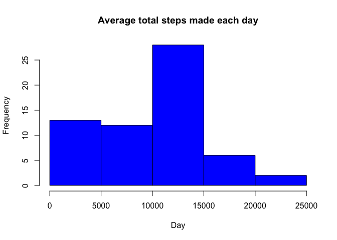

```r
totalStepsReplaced <- aggregate(steps ~ date, data = actDataReplaced, FUN=sum,
                                na.rm = TRUE)
hist(totalStepsReplaced$steps, main = "Average total steps made each day", xlab = "Day",
     col = "blue")
```

Mean value is:

```r
mean(totalStepsReplaced$steps)
```

```
## [1] 9503.869
```

Median values is:

```r
median(totalStepsReplaced$steps)
```

```
## [1] 10395
```

Check if the mean and median values after replacement changed

```r
if (mean(totalStepsReplaced$steps) != mean(totalSteps$steps)){
    sprintf(" Imputing missing values changes mean. \n")
}else{
    sprintf(" The mean value after replacement does not differ.\n")
}
```

```
## [1] " Imputing missing values changes mean. \n"
```

```r
if (median(totalStepsReplaced$steps) != median(totalSteps$steps)){
    sprintf(" IMputing missing values changes median.\n")
}else{
    sprintf(" The median value after replacement does not differ.\n")
}
```

```
## [1] " IMputing missing values changes median.\n"
```

## Are there differences in activity patterns between weekdays and weekends?

creating a new factor variable in the dataset with two levels: “weekday” and “weekend”, indicating if a given date is a weekday or weekend day. Level 1 is for a wekday, and level 2 is for a weekend.

```r
dates <- strptime(actData$date, "%Y-%m-%d")
weekDays <- dates$wday
levelDays<- weekDays
levelDays[weekDays >= 1 & weekDays <= 5] <- 1
levelDays[weekDays == 0 | weekDays == 6] <- 2
dayInWeekFactor = factor(levelDays, levels=c(1,2), labels=c("Weekdays", "Weekends"))
actData$levelOfDay<-dayInWeekFactor
```

Form two sets of data: one for weekdays and one for weekends. After that, find the mean values for intervals.

```r
actDataWeekdays <- actDataReplaced[actData$levelOfDay == "Weekdays",]
actDataWeekdaysSplit <- split(actDataWeekdays$steps, actDataWeekdays$interval)
weekdaysMean <- sapply(actDataWeekdaysSplit, FUN = mean)
actDataWeekends <- actDataReplaced[actData$levelOfDay == "Weekends",]
actDataWeekendsSplit <- split(actDataWeekends$steps, actDataWeekends$interval)
weekendsMean <- sapply(actDataWeekendsSplit, FUN = mean)
```

Making a pannel plot:

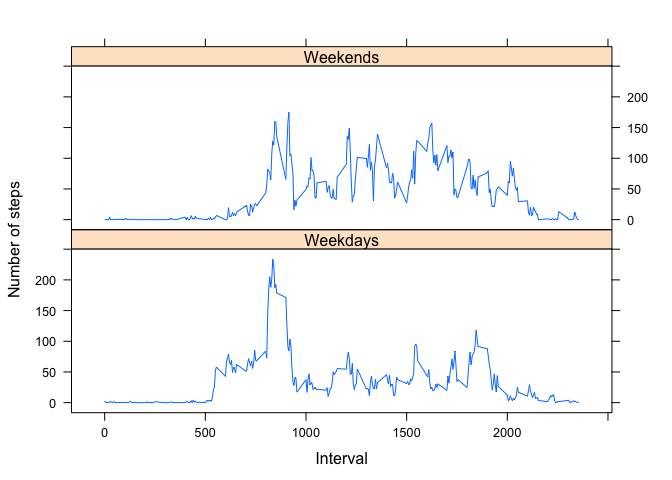

```r
library(lattice)
stepsByDay <- aggregate(steps ~ interval + actData$levelOfDay, data = actData, FUN=mean)
names(stepsByDay) <- c("interval", "levelDays", "steps")
xyplot(steps ~ interval | levelDays, stepsByDay, type = "l", layout = c(1, 2),
       xlab = "Interval", ylab = "Number of steps")
```

As seen on the figures above, there are the idifferences betweeen the weekends and weekdays.